← Voltar ao Portal

[figure not shown]

Programa 424

# Síntese Avaliativa do Desempenho dos Programas do PPA Bahia 2024–2027

# **1 - Desempenho Global do Programa**

Este documento apresenta uma Síntese Avaliativa do Desempenho do Programa do Plano Plurianual - PPA 2024- 2027, trazendo uma visão estratégica dos seus resultados, de forma sintética, transparente e colaborativa. Serão levados em consideração o Indicador Sintético de Desempenho do Programa (ISDP), a evolução dos Indicadores de Programa, a eficácia das metas dos Indicadores de Compromisso, o desempenho da execução orçamentária-financeira e da execução física das Ações orçamentárias. O ISDP é uma síntese dessas quatro dimensões, destacando o desempenho do programa em relação aos resultados obtidos e aos esforços despendidos.  
Adicionalmente, são apresentados os principais resultados alcançados, evidenciando os avanços e conformidades dos cinco programas com melhores resultados, além das oportunidades de melhoria dos cinco, com menores resultados. Enquanto neste documento a análise abrange o programa e seus componentes de maneira sintética, nos demais relatórios, a análise detalhada evidencia o comportamento dos componentes do PPA por programas e por órgãos (https://www.ba.gov.br/seplan/monitoramento-e-avaliacao/avaliacao-do-ppa). Além desta Síntese, o [Painel BI - Boletim de Avanços e Oportunidades de Melhoria](https://app.powerbi.com/view?r=eyJrIjoiN2Q0ODliNDItZDFjZi00MGM1LTliNGEtODVmZDAwZTQ1OGEyIiwidCI6IjRjZDgzNWY0LTU0NDAtNDA4Zi05M2EzLTk3NWZjMTdjMzg0YSIsImMiOjR9) oferece informações organizadas em uma perspectiva estratégica do desempenho consolidado dos programas, detalhando, no entanto, cada componente avaliado. A análise nesta seção engloba o programa e seus componentes conforme segue:

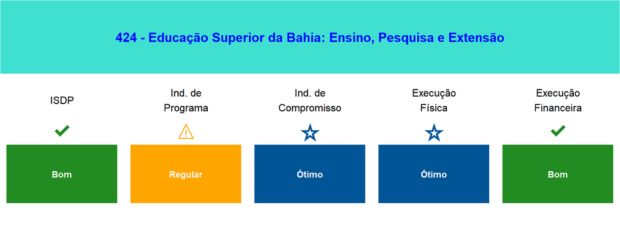

# **2 - Avanços e Conformidades no Programa**

**Indicadores de Programa:** Por fim, no programa 424 - Educação Superior da Bahia: Ensino, Pesquisa e Extensão, 60% dos indicadores mostraram evolução positiva. Um destaque é o indicador 02250, que mede a taxa ajustada de frequência escolar líquida da população de 18 a 24 anos, preta ou parda, no ensino superior, apresentando uma evolução de 33,58%. Esse resultado positivo pode ser atribuído a uma série de fatores complexos e interconectados, que vão além da atuação isolada das universidades, abrangendo políticas de acesso, permanência e ações afirmativas que vêm sendo implementadas ao longo dos anos.  
**Indicadores de Compromisso:** Por fim, no programa 424 - Educação Superior da Bahia: Ensino, Pesquisa e Extensão, 63,7% dos indicadores de compromisso foram classificados como bom ou ótimo. O destaque vai para o indicador ‘1 - Número de cursos de graduação com reconhecimento ou renovação de reconhecimento’, que alcançou 111,58%, influenciado por demandas não previstas inicialmente, como a regulamentação que exige notas mínimas para a renovação do reconhecimento. Também se destacou o indicador ‘3 - Percentual de cursos com curricularização da extensão’, que registrou 81,06%, devido a fatores conjunturais que indicam a expectativa de avanço nas próximas medições, com instituições se adaptando a novas normativas.  
**Ações Orçamentárias:** No Programa 424 - Educação Superior da Bahia: Ensino, Pesquisa e Extensão, 36,5% das ações foram avaliadas com bom ou ótimo desempenho financeiro, e 86,7% na execução física tiveram a mesma classificação. A Ação 6990 - Funcionamento de Núcleo de Inovação Tecnológica obteve classificação boa na execução financeira e ótima na física, enquanto a Ação 3424 - Concessão de Bolsa de Iniciação Científica registrou notas ótimas.

# **3 - Oportunidade de Melhoria no Programa**

**Indicadores de Programa:** No programa 424 - Educação Superior da Bahia: Ensino, Pesquisa e Extensão, 40% dos indicadores apresentaram evolução negativa. Um exemplo disso é o indicador 1457 - Taxa de Conclusão da Pós-Graduação, que registrou uma queda de 13,72%. Essa diminuição pode ser atribuída a fatores como dificuldades financeiras, a falta de tempo para estudos e o aumento das demandas profissionais, que limitam a dedicação à vida acadêmica.  
**Indicadores de Compromisso:** No Programa 424, Educação Superior da Bahia: Ensino, Pesquisa e Extensão, todos os indicadores de compromisso apresentaram desempenho satisfatório, sem registros de classificações como baixo ou muito baixo. Contudo, 36,4% dos indicadores foram considerados de desempenho indeterminado. Um destaque é o indicador de compromisso ‘1 - Número de ações de extensão desenvolvidas pelas Universidades Estaduais da Bahia (UEBA)’, que alcançou 157,04%. Esse resultado é atribuído à atuação das universidades na transformação social e no desenvolvimento sustentável das regiões onde atuam, fomentando projetos que abordam cultura e artes, entre outros temas de interesse público. Além disso, o indicador ‘1 - Percentual de execução do Plano Anual de Capacitação – PAC das Universidades’ teve um desempenho de 211,49%, reflexo do empenho das instituições em qualificar seu corpo docente por meio de políticas de formação contínua e da oferta de capacitação a distância, complementando as atividades presenciais.  
**Ações Orçamentárias:** No entanto, no Programa 424 - Educação Superior da Bahia: Ensino, Pesquisa e Extensão, 48,7% das ações foram consideradas de baixo ou muito baixo desempenho na execução financeira, enquanto 10,7% na execução física também foram classificadas assim. Exemplos são a ação 3065 - Apoio ao Mestrado e Doutorado de Profissionais da Educação Superior, que obteve execução financeira classificada como “Regular” e física como “Baixo”, e a ação 3408 - Realização de Eventos Institucionais para Integração da Educação Básica e Superior, que teve classificação “Muito Baixo”.

Desenvolvido por: DAP – Diretoria de Avaliação de Políticas Públicas